# Love Longitudinal Analyses

## Are changes in MVDPP associated with changes in love?

**Yes**. Increases in MVDPP (composite) between waves 1 and 2 were associated with increases in love (PRQC), *b* = 0.115, *p* = p<.001

```
## Linear mixed model fit by REML. t-tests use Satterthwaite's method [
## lmerModLmerTest]
## Formula: scale(prqcLove) ~ scale(w1Love) + scale(mvdppDiffComp) + (1 |
##     CIN)
##    Data: wave2
##
## REML criterion at convergence: 508.5
##
## Scaled residuals:
##     Min      1Q  Median      3Q     Max
## -3.0565 -0.3443  0.1198  0.3491  3.5200
##
## Random effects:
##  Groups   Name        Variance Std.Dev.
##  CIN      (Intercept) 0.1899   0.4358
##  Residual             0.2077   0.4557
## Number of obs: 275, groups:  CIN, 162
##
## Fixed effects:
##                        Estimate Std. Error         df t value Pr(>|t|)
## (Intercept)           -0.002295   0.044389 160.737761  -0.052 0.958823
## scale(w1Love)          0.743434   0.039711 258.020352  18.721  < 2e-16 ***
## scale(mvdppDiffComp)   0.114615   0.033842 228.618681   3.387 0.000832 ***
## ---
## Signif. codes:  0 '***' 0.001 '**' 0.01 '*' 0.05 '.' 0.1 ' ' 1
##
## Correlation of Fixed Effects:
##             (Intr) sc(1L)
## scale(w1Lv) -0.022
## scl(mvdpDC) -0.017  0.012
```

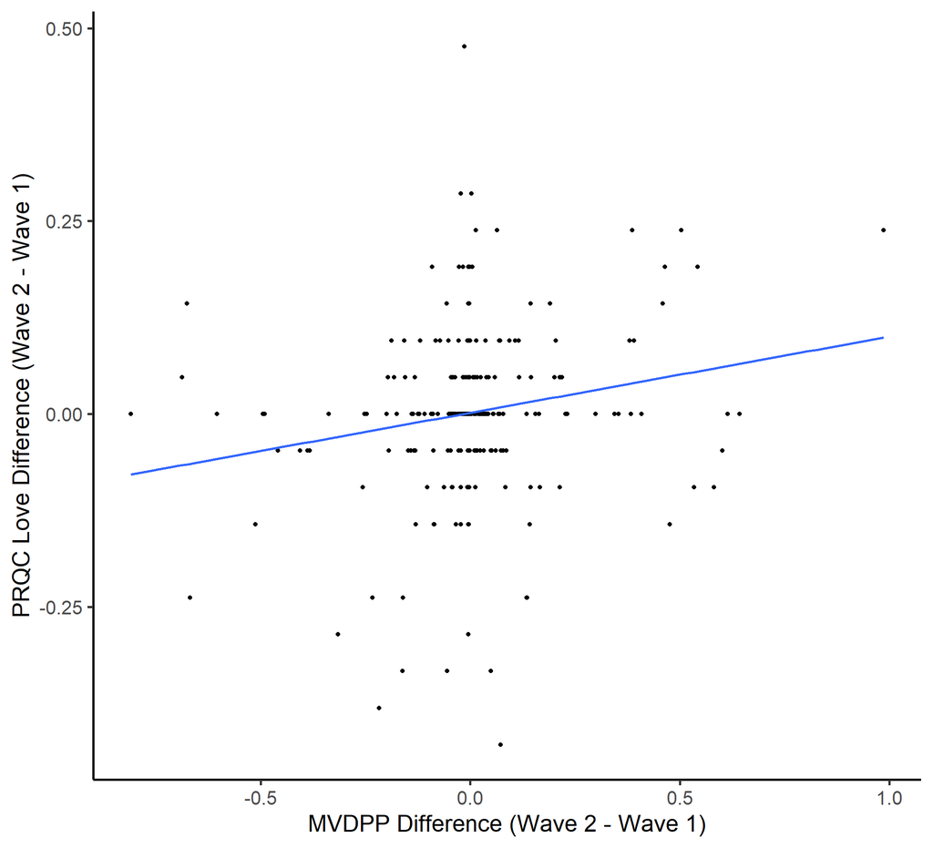

Figure 1. Change in love between waves 1 and 2 as a function of changes in MVDPP (composite).

This is true even when using mate-rated MVDPP, *b* = 0.136, *p* = p<.001.

```
## Linear mixed model fit by REML. t-tests use Satterthwaite's method [
## lmerModLmerTest]
## Formula: scale(prqcLove) ~ scale(w1Love) + scale(mvdppDiffMR) + (1 | CIN)
##    Data: wave2
##
## REML criterion at convergence: 504.9
##
## Scaled residuals:
##     Min      1Q  Median      3Q     Max
## -3.0213 -0.4021  0.1164  0.3555  3.4980
##
## Random effects:
##  Groups   Name        Variance Std.Dev.
##  CIN      (Intercept) 0.1961   0.4428
##  Residual             0.2001   0.4473
## Number of obs: 275, groups:  CIN, 162
##
## Fixed effects:
##                     Estimate Std. Error        df t value Pr(>|t|)
## (Intercept)        8.495e-05  4.450e-02 1.591e+02   0.002 0.998479
## scale(w1Love)      7.345e-01  3.957e-02 2.593e+02  18.561  < 2e-16 ***
## scale(mvdppDiffMR) 1.361e-01  3.487e-02 2.246e+02   3.903 0.000126 ***
## ---
## Signif. codes:  0 '***' 0.001 '**' 0.01 '*' 0.05 '.' 0.1 ' ' 1
##
## Correlation of Fixed Effects:
##             (Intr) sc(1L)
## scale(w1Lv) -0.022
## scl(mvdDMR) -0.002 -0.032
```

The relationship between change in MVDPP and change in love is lower when controlling for change in satisfaction, *b* = 0.079, *p* = 0.04. However, a bootstrap analysis indicates that this was not a significant decrease, *diff* = 0.036, 95% CI [-0.091,0.16], meaning we do not have significant evidence of mediation of the relationship between MVDPP and love by satisfaction.

The relationship between change in MVDPP and change in love is no longer significant when controlling for change in commitment, *b* = 0.073, *p* = 0.051. However, a bootstrap analysis indicates that this was not a significant decrease, *diff* = 0.042, 95% CI [-0.047,0.139], meaning we do not have significant evidence of mediation of the relationship between MVDPP and love by commitment.

## Does love moderate the relationship between change in MVDPP and satisfaction or commitment?

### Satisfaction

For satisfaction, Wave 1 love did not moderate the relationship between change in MVDPP (composite) and changes in feelings of satisfaction, *b* = -0.054, *p* = 0.127

```
## Linear mixed model fit by REML. t-tests use Satterthwaite's method [
## lmerModLmerTest]
## Formula:
## scale(satComp) ~ scale(w1Sat) + scale(mvdppDiffComp) * scale(w1Love) +
##     (1 | CIN)
##    Data: wave2
##
## REML criterion at convergence: 277.4
##
## Scaled residuals:
##     Min      1Q  Median      3Q     Max
## -3.8536 -0.2461  0.0156  0.3069  2.0422
##
## Random effects:
##  Groups   Name        Variance Std.Dev.
##  CIN      (Intercept) 0.1768   0.4204
##  Residual             0.1224   0.3499
## Number of obs: 170, groups:  CIN, 131
##
## Fixed effects:
##                                     Estimate Std. Error        df t value
## (Intercept)                          0.05759    0.04646 131.04517   1.239
## scale(w1Sat)                         0.57008    0.06955 150.06784   8.196
## scale(mvdppDiffComp)                 0.14136    0.04140 150.28659   3.414
## scale(w1Love)                        0.27723    0.07410 147.54932   3.741
## scale(mvdppDiffComp):scale(w1Love)  -0.05351    0.03472  88.98766  -1.541
##                                    Pr(>|t|)
## (Intercept)                        0.217396
## scale(w1Sat)                       1.02e-13 ***
## scale(mvdppDiffComp)               0.000822 ***
## scale(w1Love)                      0.000262 ***
## scale(mvdppDiffComp):scale(w1Love) 0.126789
## ---
## Signif. codes:  0 '***' 0.001 '**' 0.01 '*' 0.05 '.' 0.1 ' ' 1
##
## Correlation of Fixed Effects:
##             (Intr) sc(1S) sc(DC) sc(1L)
## scale(w1St)  0.089
## scl(mvdpDC) -0.023  0.048
## scale(w1Lv) -0.119 -0.809 -0.033
## sc(DC):(1L)  0.058  0.012  0.352 -0.179
```

```
## Linear mixed model fit by REML. t-tests use Satterthwaite's method [
## lmerModLmerTest]
## Formula:
## scale(satComp) ~ scale(w1Sat) + scale(mvdppDiffComp) * scale(prqcLove) +
##     (1 | CIN)
##    Data: wave2
##
## REML criterion at convergence: 307.4
##
## Scaled residuals:
##     Min      1Q  Median      3Q     Max
## -4.4756 -0.2556  0.0330  0.3565  3.0039
##
## Random effects:
##  Groups   Name        Variance Std.Dev.
##  CIN      (Intercept) 0.15533  0.3941
##  Residual             0.09764  0.3125
## Number of obs: 220, groups:  CIN, 149
##
## Fixed effects:
##                                       Estimate Std. Error        df t value
## (Intercept)                          4.065e-03  3.917e-02 1.368e+02   0.104
## scale(w1Sat)                         3.571e-01  5.132e-02 2.130e+02   6.957
## scale(mvdppDiffComp)                 8.994e-02  3.423e-02 2.053e+02   2.628
## scale(prqcLove)                      5.614e-01  5.112e-02 2.138e+02  10.983
## scale(mvdppDiffComp):scale(prqcLove) 4.798e-03  2.837e-02 1.588e+02   0.169
##                                      Pr(>|t|)
## (Intercept)                           0.91749
## scale(w1Sat)                         4.21e-11 ***
## scale(mvdppDiffComp)                  0.00924 **
## scale(prqcLove)                       < 2e-16 ***
## scale(mvdppDiffComp):scale(prqcLove)  0.86592
## ---
## Signif. codes:  0 '***' 0.001 '**' 0.01 '*' 0.05 '.' 0.1 ' ' 1
##
## Correlation of Fixed Effects:
##             (Intr) sc(1S) sc(DC) scl(L)
## scale(w1St)  0.035
## scl(mvdpDC) -0.028  0.155
## scl(prqcLv) -0.047 -0.739 -0.162
## scl(DC):(L) -0.057 -0.023  0.335 -0.102
```

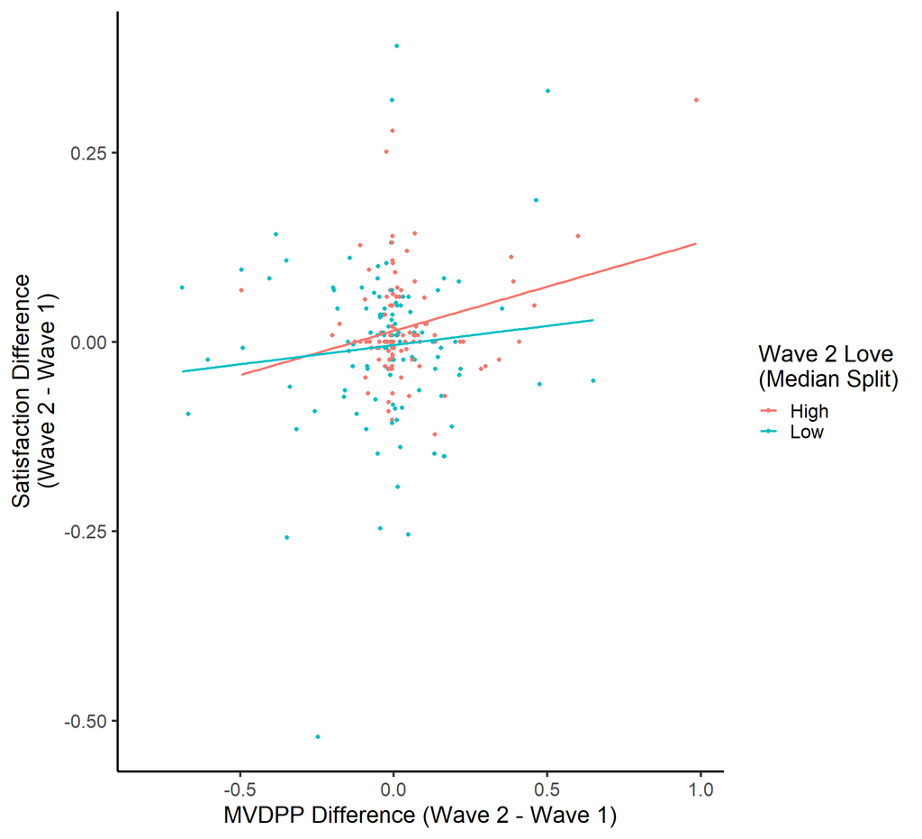

Figure 2. Changes in satisfaction as a function of changes in MVDP, moderated by feelings of love at Wave 2 (“High” means above median; “Low” means at or below median).

### Commitment

For commitment, Wave 2 love did not moderate the relationship between change in MVDPP (composite) and changes in feelings of commitment, *b* = -0.046, *p* = 0.111

```
## Linear mixed model fit by REML. t-tests use Satterthwaite's method [
## lmerModLmerTest]
## Formula:
## scale(prqcComm) ~ scale(w1Comm) + scale(mvdppDiffComp) * scale(prqcLove) +
##     (1 | CIN)
##    Data: wave2
##
## REML criterion at convergence: 479.2
##
## Scaled residuals:
##     Min      1Q  Median      3Q     Max
## -3.5351 -0.2421 -0.0310  0.4290  3.6474
##
## Random effects:
##  Groups   Name        Variance Std.Dev.
##  CIN      (Intercept) 0.1629   0.4036
##  Residual             0.1769   0.4205
## Number of obs: 279, groups:  CIN, 164
##
## Fixed effects:
##                                       Estimate Std. Error        df t value
## (Intercept)                            0.01634    0.04087 146.19823   0.400
## scale(w1Comm)                          0.30096    0.04940 268.40782   6.092
## scale(mvdppDiffComp)                   0.03241    0.03568 267.25276   0.909
## scale(prqcLove)                        0.50864    0.04858 273.99182  10.471
## scale(mvdppDiffComp):scale(prqcLove)  -0.04631    0.02893 239.26472  -1.600
##                                      Pr(>|t|)
## (Intercept)                             0.690
## scale(w1Comm)                        3.85e-09 ***
## scale(mvdppDiffComp)                    0.364
## scale(prqcLove)                       < 2e-16 ***
## scale(mvdppDiffComp):scale(prqcLove)    0.111
## ---
## Signif. codes:  0 '***' 0.001 '**' 0.01 '*' 0.05 '.' 0.1 ' ' 1
##
## Correlation of Fixed Effects:
##             (Intr) sc(1C) sc(DC) scl(L)
## scal(w1Cmm) -0.016
## scl(mvdpDC) -0.048  0.108
## scl(prqcLv)  0.008 -0.638 -0.141
## scl(DC):(L) -0.063 -0.047  0.330 -0.072
```

Wave 1 love *did* moderate the relationship between change in MVDPP (composite) and changes in commitment in the direction predicted by the commitment device hypothesis, *b* = -0.128, *p* = p<.001. People more in love showed *less* change in commitment as a function of changes in MVDPP.

```
## Linear mixed model fit by REML. t-tests use Satterthwaite's method [
## lmerModLmerTest]
## Formula:
## scale(prqcComm) ~ scale(w1Comm) + scale(mvdppDiffComp) * scale(w1Love) +
##     (1 | CIN)
##    Data: wave2
##
## REML criterion at convergence: 458.3
##
## Scaled residuals:
##     Min      1Q  Median      3Q     Max
## -4.0526 -0.1598  0.0705  0.2979  2.5465
##
## Random effects:
##  Groups   Name        Variance Std.Dev.
##  CIN      (Intercept) 0.298    0.5459
##  Residual             0.185    0.4301
## Number of obs: 226, groups:  CIN, 153
##
## Fixed effects:
##                                     Estimate Std. Error        df t value
## (Intercept)                          0.01580    0.05335 135.94541   0.296
## scale(w1Comm)                        0.40955    0.06652 195.75859   6.157
## scale(mvdppDiffComp)                 0.06963    0.04278 182.32254   1.628
## scale(w1Love)                        0.26818    0.06372 157.37812   4.209
## scale(mvdppDiffComp):scale(w1Love)  -0.12758    0.03559 135.89259  -3.585
##                                    Pr(>|t|)
## (Intercept)                        0.767626
## scale(w1Comm)                      4.13e-09 ***
## scale(mvdppDiffComp)               0.105333
## scale(w1Love)                      4.30e-05 ***
## scale(mvdppDiffComp):scale(w1Love) 0.000469 ***
## ---
## Signif. codes:  0 '***' 0.001 '**' 0.01 '*' 0.05 '.' 0.1 ' ' 1
##
## Correlation of Fixed Effects:
##             (Intr) sc(1C) sc(DC) sc(1L)
## scal(w1Cmm)  0.001
## scl(mvdpDC) -0.033  0.011
## scale(w1Lv) -0.031 -0.670 -0.044
## sc(DC):(1L)  0.024 -0.052  0.370 -0.157
```

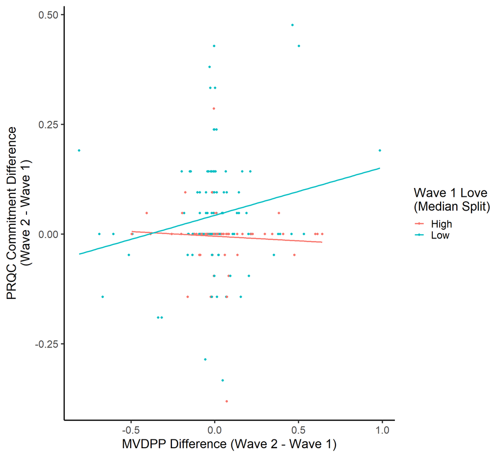

Figure 3.Changes in commitment as a function of changes in MVDP, moderated by feelings of love at Wave 1 (“High” means above median; “Low” means at or below median).

However, this was not significant when using mate-rated MVDPP, *b* = -0.04, *p* = 0.395.

Furthermore, given that love is correlated with both (1) feelings of commitment and (2) MVDPP—and changes in both of these variables—it is possible that this reflects a ceiling effect. Indeed, people who were high in love at Wave 1 tended to be high in MVDPP and commitment at both waves 1 and 2 and show less extreme changes in MVDPP across waves. The apparent moderation therefore might be just an artifact of a ceiling effect where in people who are high in love have less room to change in MVDPP or commitment.

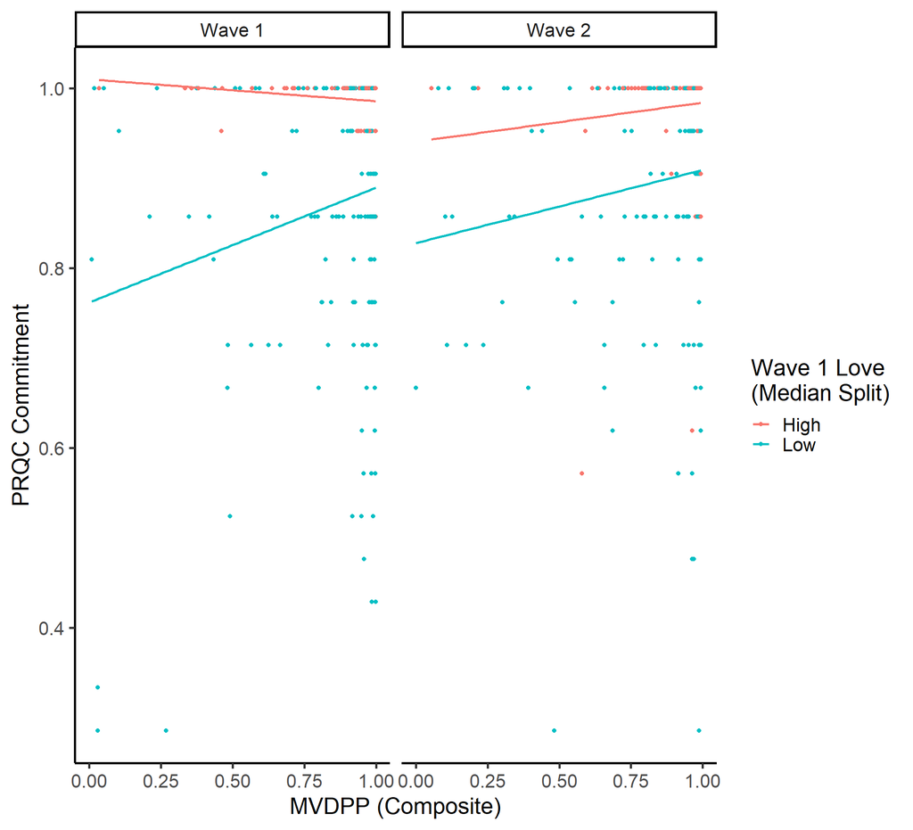

Figure 4. Commitment as a function of MVDPP and Love across Waves 1 and 2

```
## $High
##    Min. 1st Qu.  Median    Mean 3rd Qu.    Max.
## 0.03456 0.92580 0.99166 0.92345 0.99881 0.99881
##
## $Low
##     Min.  1st Qu.   Median     Mean  3rd Qu.     Max.
## 0.008343 0.798570 0.961859 0.837670 0.996424 0.998808
```

```
## $High
##    Min. 1st Qu.  Median    Mean 3rd Qu.    Max.    NA's
## 0.05422 0.95181 0.98193 0.93248 0.99398 0.99398       4
##
## $Low
##    Min. 1st Qu.  Median    Mean 3rd Qu.    Max.    NA's
##  0.0000  0.7651  0.9518  0.8270  0.9940  0.9940      18
```

```
## $High
##      Min.   1st Qu.    Median      Mean   3rd Qu.      Max.      NA's
## -0.494694 -0.022904 -0.004832  0.008126  0.024965  0.642173         4
##
## $Low
##      Min.   1st Qu.    Median      Mean   3rd Qu.      Max.      NA's
## -0.809326 -0.051998 -0.004832 -0.003808  0.049349  0.985633        18
```

```
## $High
##    Min. 1st Qu.  Median    Mean 3rd Qu.    Max.    NA's
##  0.7143  1.0000  1.0000  0.9877  1.0000  1.0000      22
##
## $Low
##    Min. 1st Qu.  Median    Mean 3rd Qu.    Max.    NA's
##  0.2857  0.7738  0.8571  0.8545  1.0000  1.0000      33
```

```
## $High
##    Min. 1st Qu.  Median    Mean 3rd Qu.    Max.    NA's
##  0.5714  1.0000  1.0000  0.9812  1.0000  1.0000       4
##
## $Low
##    Min. 1st Qu.  Median    Mean 3rd Qu.    Max.    NA's
##  0.2857  0.8571  0.9048  0.8869  1.0000  1.0000      18
```

### Summary

Overall, we see that changes in MVDPP across time are *positively* associated with changes in love across time, such that people feel *less* in love when their partner when they have more quality alternatives. This is directly contrary to the hypothesis that love acts as a commitment device. However, we did not find significant evidence of mediation of the relationship between MVDPP and love by satisfaction for commitment. Furthermore, caution in interpretation is still warranted as these data still do not allow teasing apart direction of causality.

The commitment device hypothesis instead received only mixed support. Love did not appear to blunt the relationship between MVDPP and satisfaction—in fact, if anything, people in love were *more* sensitive to MVDPP in terms of their satisfaction. Love *did* appear to blunt the relationship between MVDPP and feelings of commitment, but only for wave 1 love and only for composite MVDPP. Even this effect seemed to be driven by a ceiling effect that is in fact consistent with the relationship maintenance hypothesis.